# R Notebook

Hi MLEnthusiasts! Today, we will learn how to implement logistic regression using R that too on a well-known dataset, The Titanic Dataset! So, our analysis becomes by getting some information about the dataset, like what all variables are in our dataset and what do we have to predict.

The dataset can be found on this link of kaggle. Following are the variables of this dataset: survival: Tells whether a particular passenger survived or not. 0 for not survived, 1 for survived. pClass: Ticket class, 1 for 1st class, 2 for 2nd class and 3 for 3rd class. sex: Tells us the gender of the passenger Age: in years sibsp: # of siblings or spouses aboarding the titanic parch: # of parents/children of the passenger fare: passenger fare embarked: The port of embarkment; C for Cherbourg, Q for Queenstown and S for Southampton

Having seen what the data is all about, let’s also understand the problem statement. The problem is to make a logistic regression model using all the variables mentioned above with dependent variable being Survived and other variables being independent. Thus, it will be a predictive model which predicts whether a passenger having given parameters will survive or not. By looking closely at the problem, we can say that it’s a binary classification problem(0/1) or logistic regression problem.

Let us first set our working directory and import our dataset.

```r
setwd("C:/Users/jyoti/Downloads/LogisticRegression")
data <- read.csv("titanic.csv")
```

Here, data is a dataframe having all the variables and data of those variables. The dataframe has 1257 observations of 9 variables. The next step is to view the data inside the dataframe.

```r
View(data)
```

Now starts the first main step, “Data Preparation”. To see if there is any missing data or to know about the mean or standard deviation, we use the summary() function.

```r
summary(data)
```

```
     pclass        survived                                    name
 Min.   :1.00   Min.   :0.0000   Connolly, Miss. Kate            :   2
 1st Qu.:2.00   1st Qu.:0.0000   Kelly, Mr. James                :   2
 Median :3.00   Median :0.0000   Abbing, Mr. Anthony             :   1
 Mean   :2.31   Mean   :0.3827   Abbott, Master. Eugene Joseph   :   1
 3rd Qu.:3.00   3rd Qu.:1.0000   Abbott, Mr. Rossmore Edward     :   1
 Max.   :3.00   Max.   :1.0000   Abbott, Mrs. Stanton (Rosa Hunt):   1
                                 (Other)                         :1249
     sex           age            sibsp           parch
 female:452   Min.   : 1.00   Min.   :0.000   Min.   :0.0000
 male  :805   1st Qu.:21.00   1st Qu.:0.000   1st Qu.:0.0000
              Median :28.00   Median :0.000   Median :0.0000
              Mean   :29.07   Mean   :0.502   Mean   :0.3779
              3rd Qu.:37.00   3rd Qu.:1.000   3rd Qu.:0.0000
              Max.   :60.00   Max.   :8.000   Max.   :9.0000
              NA's   :261
      fare         embarked
 Min.   :  0.000   C:256
 1st Qu.:  7.896   Q:119
 Median : 14.400   S:882
 Mean   : 32.721
 3rd Qu.: 31.000
 Max.   :512.329
```

As can be seen, there are 261 missing values in the Age variable. We need to do missing value imputation in this case. But, before doing that, we need to check how the age distribution looks like so that we can know which imputation method to choose and apply.

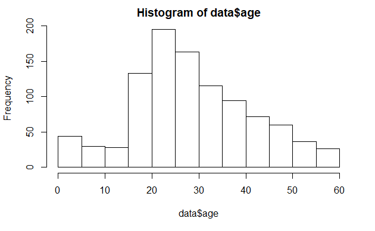

```r
hist(data$age)
```

Since the distribution looks somewhat normal, we can use mean value imputation in this case. That is, we can replace the missing values with the mean of the age. This doesn’t deviate the mean and the distribution of the age remains the same.

```r
data$age[is.na(data$age)] = 29.07
summary(data)
```

```
     pclass        survived                                    name
 Min.   :1.00   Min.   :0.0000   Connolly, Miss. Kate            :   2
 1st Qu.:2.00   1st Qu.:0.0000   Kelly, Mr. James                :   2
 Median :3.00   Median :0.0000   Abbing, Mr. Anthony             :   1
 Mean   :2.31   Mean   :0.3827   Abbott, Master. Eugene Joseph   :   1
 3rd Qu.:3.00   3rd Qu.:1.0000   Abbott, Mr. Rossmore Edward     :   1
 Max.   :3.00   Max.   :1.0000   Abbott, Mrs. Stanton (Rosa Hunt):   1
                                 (Other)                         :1249
     sex           age            sibsp           parch
 female:452   Min.   : 1.00   Min.   :0.000   Min.   :0.0000
 male  :805   1st Qu.:22.00   1st Qu.:0.000   1st Qu.:0.0000
              Median :29.07   Median :0.000   Median :0.0000
              Mean   :29.07   Mean   :0.502   Mean   :0.3779
              3rd Qu.:34.00   3rd Qu.:1.000   3rd Qu.:0.0000
              Max.   :60.00   Max.   :8.000   Max.   :9.0000

      fare         embarked
 Min.   :  0.000   C:256
 1st Qu.:  7.896   Q:119
 Median : 14.400   S:882
 Mean   : 32.721
 3rd Qu.: 31.000
 Max.   :512.329
```

As can be seen above, age doesn’t have any missing value now. Let’s see how the data looks like now.

```r
head(data)
```

|  | pclass | survived | name | sex | age | sibsp | parch | fare | embarked |
| --- | --- | --- | --- | --- | --- | --- | --- | --- | --- |
| 1 | 1 | 1 | Allen, Miss. Elisabeth Walton | female | 29 | 0 | 0 | 211.3375 | S |
| 2 | 1 | 0 | Allison, Miss. Helen Loraine | female | 2 | 1 | 2 | 151.5500 | S |
| 3 | 1 | 0 | Allison, Mr. Hudson Joshua Creighton | male | 30 | 1 | 2 | 151.5500 | S |
| 4 | 1 | 0 | Allison, Mrs. Hudson J C (Bessie Waldo Daniels) | female | 25 | 1 | 2 | 151.5500 | S |
| 5 | 1 | 1 | Anderson, Mr. Harry | male | 48 | 0 | 0 | 26.5500 | S |
| 6 | 1 | 0 | Andrews, Mr. Thomas Jr | male | 39 | 0 | 0 | 0.0000 | S |

Now, let us understand the concept of dummy variables. Suppose a variable “A” has n classes. This variable A can be replaced by n-1 variables. If A has i, j, k, …, classes, then A_i = 1 in the rows at which i appears in A’s column and 0 for the rest of the rows. Same applies for j, k.. etc. The last value gets taken care of by the intercept. So, let’s introduce dummy variables inside our data for sex and embarked columns since they are holding the categorical data.

```r
data$female = ifelse(data$sex=="female", 1, 0)
data$embarked_c = ifelse(data$embarked=="C", 1, 0)
data$embarked_s = ifelse(data$embarked=="S", 1, 0)
head(data)
```

|  | pclass | survived | name | sex | age | sibsp | parch | fare | embarked | female | embarked_c | embarked_s |
| --- | --- | --- | --- | --- | --- | --- | --- | --- | --- | --- | --- | --- |
| 1 | 1 | 1 | Allen, Miss. Elisabeth Walton | female | 29 | 0 | 0 | 211.3375 | S | 1 | 0 | 1 |
| 2 | 1 | 0 | Allison, Miss. Helen Loraine | female | 2 | 1 | 2 | 151.5500 | S | 1 | 0 | 1 |
| 3 | 1 | 0 | Allison, Mr. Hudson Joshua Creighton | male | 30 | 1 | 2 | 151.5500 | S | 0 | 0 | 1 |
| 4 | 1 | 0 | Allison, Mrs. Hudson J C (Bessie Waldo Daniels) | female | 25 | 1 | 2 | 151.5500 | S | 1 | 0 | 1 |
| 5 | 1 | 1 | Anderson, Mr. Harry | male | 48 | 0 | 0 | 26.5500 | S | 0 | 0 | 1 |
| 6 | 1 | 0 | Andrews, Mr. Thomas Jr | male | 39 | 0 | 0 | 0.0000 | S | 0 | 0 | 1 |

Now, if you have a look at dataframe, it contains 12 variables and not 9. The next step is to remove those variables which we no longer need, name, sex since it is already taken into account by female variable, embarked, i.e. column number 3, 4 and 9.

```r
data = data[-c(3, 4, 9)]
head(data)
```

|  | pclass | survived | age | sibsp | parch | fare | female | embarked_c | embarked_s |
| --- | --- | --- | --- | --- | --- | --- | --- | --- | --- |
| 1 | 1 | 1 | 29 | 0 | 0 | 211.3375 | 1 | 0 | 1 |
| 2 | 1 | 0 | 2 | 1 | 2 | 151.5500 | 1 | 0 | 1 |
| 3 | 1 | 0 | 30 | 1 | 2 | 151.5500 | 0 | 0 | 1 |
| 4 | 1 | 0 | 25 | 1 | 2 | 151.5500 | 1 | 0 | 1 |
| 5 | 1 | 1 | 48 | 0 | 0 | 26.5500 | 0 | 0 | 1 |
| 6 | 1 | 0 | 39 | 0 | 0 | 0.0000 | 0 | 0 | 1 |

Let’s do univariate analysis of the numerical variables, age and fare now.

[figure not shown]

```r
bx = boxplot(data$age)
```

Thus, there are outliers in the age variable and we need to do outlier handling in this case.

```r
bx$stats
```

```
      [,1]
[1,]  4.00
[2,] 22.00
[3,] 29.07
[4,] 34.00
[5,] 52.00
```

```r
quantile(data$age, seq(0, 1, 0.02))
```

[output not shown]

We can replace the outliers above 96% of the quantile range and below 4% of the quantile range so that more accuracy is obtained and the data loss is also not very significant.

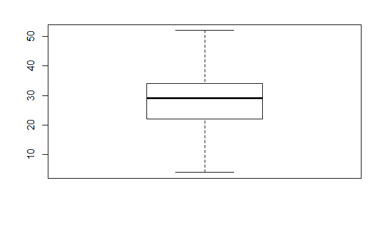

```r
data$age = ifelse(data$age>=52, 52, data$age)
data$age = ifelse(data$age<=4, 4, data$age)
boxplot(data$age)
```

The boxplot comes out to be neat in this case after outlier handling. Let us now do analysis for fare variable.

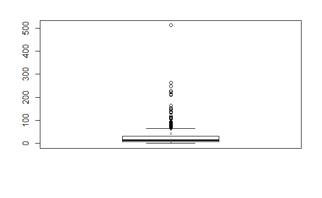

```r
bx = boxplot(data$fare)
```

```r
bx$stats
```

```
        [,1]
[1,]  0.0000
[2,]  7.8958
[3,] 14.4000
[4,] 31.0000
[5,] 65.0000
```

Thus, there is a very large amount of outlier data on the upper end.

```r
quantile(data$fare, seq(0, 1, 0.02))
```

```
        0%         2%         4%         6%         8%        10%
  0.000000   6.495800   7.125000   7.229200   7.250000   7.550000
       12%        14%        16%        18%        20%        22%
  7.740524   7.750000   7.750000   7.775000   7.854200   7.879200
       24%        26%        28%        30%        32%        34%
  7.895800   7.895800   7.925000   8.050000   8.050000   8.662500
       36%        38%        40%        42%        44%        46%
  9.034672   9.838676  10.500000  11.760000  13.000000  13.000000
       48%        50%        52%        54%        56%        58%
 13.000000  14.400000  15.045800  15.550000  16.100000  20.212500
       60%        62%        64%        66%        68%        70%
 21.045000  23.250000  25.895672  26.000000  26.020000  26.550000
       72%        74%        76%        78%        80%        82%
 27.900000  30.000000  31.387500  36.350000  39.687500  50.456136
       84%        86%        88%        90%        92%        94%
 53.176000  59.400000  69.550000  76.952520  83.158300 108.009000
       96%        98%       100%
136.504184 211.500000 512.329200
```

As can be seen above, the major difference between the values arises above 96% of the quantile.

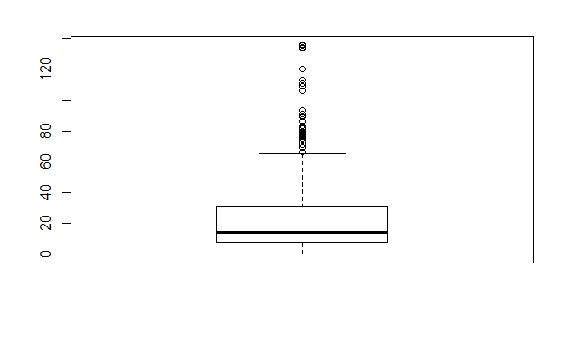

```r
data$fare = ifelse(data$fare>=136, 136, data$fare)
boxplot(data$fare)
```

Let us now start our bivariate analysis.

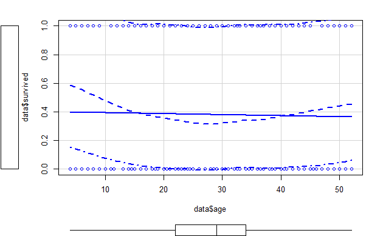

```r
library(car)
scatterplot(data$age, data$survived)
```

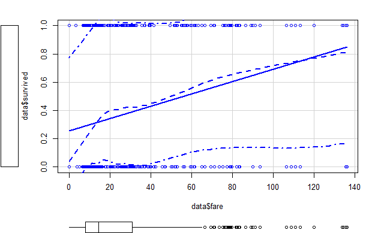

```r
scatterplot(data$fare, data$survived)
```

Let’s now divide the data into train and test sets.

```r
set.seed(222)
t= sample(1:nrow(data), 0.7*nrow(data))
train = data[t,]
test = data[-t,]
```

Here, we have taken the train to test ratio as 7:3. Let’s now make a model and check for multi-collinearity using variance inflation factor technique.

```r
library(car)
model <- lm(survived~., data=train)
t = vif(model)
sort(t, decreasing=TRUE)
```

```
embarked_c embarked_s       fare     pclass      parch      sibsp
  2.813592   2.687370   2.461220   2.372068   1.325070   1.321560
       age     female
  1.196365   1.120959
```

As you can see, all the values of VIF for all the variables are less than 5, we need not reject any varible and we can straight away start our analysis.

```r
model1<- glm(as.factor(survived)~., family="binomial", data=train)
summary(model1)
```

```
Call:
glm(formula = as.factor(survived) ~ ., family = "binomial", data = train)

Deviance Residuals:
    Min       1Q   Median       3Q      Max
-2.4459  -0.6413  -0.4295   0.6550   2.5902

Coefficients:
             Estimate Std. Error z value Pr(>|z|)
(Intercept)  1.711050   0.685539   2.496  0.01256 *
pclass      -0.964057   0.162430  -5.935 2.93e-09 ***
age         -0.027928   0.008984  -3.109  0.00188 **
sibsp       -0.295096   0.113817  -2.593  0.00952 **
parch       -0.107448   0.112876  -0.952  0.34114
fare         0.000588   0.004208   0.140  0.88887
female       2.667516   0.198462  13.441  < 2e-16 ***
embarked_c   0.511851   0.361509   1.416  0.15681
embarked_s  -0.348231   0.313073  -1.112  0.26601
---
Signif. codes:  0 ‘***’ 0.001 ‘**’ 0.01 ‘*’ 0.05 ‘.’ 0.1 ‘ ’ 1

(Dispersion parameter for binomial family taken to be 1)

    Null deviance: 1162.39  on 878  degrees of freedom
Residual deviance:  789.76  on 870  degrees of freedom
AIC: 807.76

Number of Fisher Scoring iterations: 5
```

```r
stepmodel = step(model1, direction="both")
```

```
Start:  AIC=807.76
as.factor(survived) ~ pclass + age + sibsp + parch + fare + female +
    embarked_c + embarked_s

             Df Deviance     AIC
- fare        1   789.77  805.77
- parch       1   790.69  806.69
- embarked_s  1   790.98  806.98
<none>            789.76  807.76
- embarked_c  1   791.78  807.78
- sibsp       1   797.53  813.53
- age         1   799.66  815.66
- pclass      1   826.11  842.11
- female      1  1014.99 1030.99

Step:  AIC=805.77
as.factor(survived) ~ pclass + age + sibsp + parch + female +
    embarked_c + embarked_s

             Df Deviance     AIC
- parch       1   790.72  804.72
- embarked_s  1   791.05  805.05
<none>            789.77  805.77
- embarked_c  1   791.85  805.85
+ fare        1   789.76  807.76
- sibsp       1   798.04  812.04
- age         1   799.72  813.72
- pclass      1   858.03  872.03
- female      1  1016.05 1030.05

Step:  AIC=804.72
as.factor(survived) ~ pclass + age + sibsp + female + embarked_c +
    embarked_s

             Df Deviance     AIC
- embarked_s  1   792.33  804.33
- embarked_c  1   792.52  804.52
<none>            790.72  804.72
+ parch       1   789.77  805.77
+ fare        1   790.69  806.69
- age         1   800.80  812.80
- sibsp       1   802.08  814.08
- pclass      1   859.80  871.80
- female      1  1022.31 1034.31

Step:  AIC=804.33
as.factor(survived) ~ pclass + age + sibsp + female + embarked_c

             Df Deviance     AIC
<none>            792.33  804.33
+ embarked_s  1   790.72  804.72
+ parch       1   791.05  805.05
+ fare        1   792.32  806.32
- age         1   801.86  811.86
- sibsp       1   805.17  815.17
- embarked_c  1   806.55  816.55
- pclass      1   860.48  870.48
- female      1  1035.40 1045.40
```

```r
formula(stepmodel)
```

```
as.factor(survived) ~ pclass + age + sibsp + female + embarked_c
```

```r
summary(stepmodel)
```

```
Call:
glm(formula = as.factor(survived) ~ pclass + age + sibsp + female +
    embarked_c, family = "binomial", data = train)

Deviance Residuals:
    Min       1Q   Median       3Q      Max
-2.4341  -0.6484  -0.4317   0.6472   2.5857

Coefficients:
             Estimate Std. Error z value Pr(>|z|)
(Intercept)  1.340344   0.459300   2.918 0.003520 **
pclass      -0.944959   0.119134  -7.932 2.16e-15 ***
age         -0.027296   0.008952  -3.049 0.002295 **
sibsp       -0.340258   0.105624  -3.221 0.001276 **
female       2.661388   0.190473  13.973  < 2e-16 ***
embarked_c   0.835246   0.221760   3.766 0.000166 ***
---
Signif. codes:  0 ‘***’ 0.001 ‘**’ 0.01 ‘*’ 0.05 ‘.’ 0.1 ‘ ’ 1

(Dispersion parameter for binomial family taken to be 1)

    Null deviance: 1162.39  on 878  degrees of freedom
Residual deviance:  792.33  on 873  degrees of freedom
AIC: 804.33

Number of Fisher Scoring iterations: 5
```

Thus, now the main formula becomes as.factor(survived) ~ pclass + age + sibsp + female + embarked_c. Now, we can use stepmodel to predict the score for train dataset.

```r
train$score <- predict(stepmodel, newdata = train, type="response")
head(train$score)
```

```
[1] 0.09212068 0.31194682 0.14790780 0.90595397 0.10184237 0.18957629
```

```r
tail(train$score)
```

```
[1] 0.3448299 0.7656246 0.5763930 0.7224989 0.5082788 0.1043664
```

These are the probabilities values of whether the corresponding passenger survived or not. Let’s now start the model evaluation.

```r
library(lattice)
library(ggplot2)
library(caret)
library(e1071)
train$prediction <- ifelse(train$score>=0.6, 1, 0)
table(factor(train$prediction), factor(train$survived))
```

```
      0   1
  0 508 132
  1  42 197
```

Thus, accuracy = (TP+TN)/(TP+TN+FP+FN)=(508+197)/(508+197+42+132)=705/879=0.802=80.2%. Now, let’s check the ROC and AUC curves of the model.

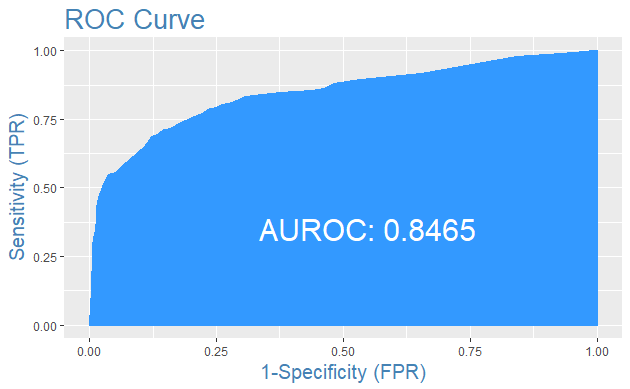

```r
library(InformationValue)
plotROC(actuals=train$survived, predictedScores=as.numeric(fitted(stepmodel)))
```

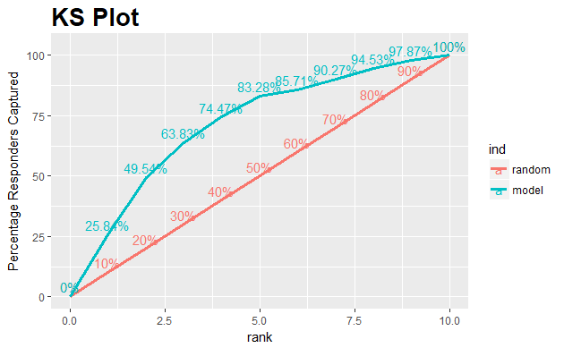

```r
ks_plot(actuals=train$survived, predictedScores=as.numeric(fitted(stepmodel)))
```

```r
test$score<-predict(stepmodel, test, type = "response")
head(test$score)
```

```
[1] 0.3178353 0.9622005 0.9534058 0.5616826 0.2779192 0.9396649
```

Let’s set the threshold to 0.6.

```r
test$predicted<-ifelse(test$score>=0.6, 1, 0)
head(test$predicted)
```

```
[1] 0 1 1 0 0 1
```

Let’s now have a look at the confusion matrix for test dataset.

```r
table(factor(test$predicted), factor(test$survived))
```

```
      0   1
  0 209  63
  1  17  89
```